# Using the assertr package

[Download Materials](https://github.com/DavidMartinConsulting/DM_Consulting/blob/gh-pages/assertr.zip?raw=true)

# assertr

The purpose of this document is to go over the package `assertr`, a package that is useful in testing out assumptions about a dataset before undertaking data analysis.

```r
# install.packages("assertr")
library(assertr)
```

# `assertr` functions

The main functions from the `assertr` functions are - `assert`: takes a data frame, a predicate function, and an arbitrary number of columns to apply the predicate function to. The predicate function (a function that returns a logical/boolean value) is then applied to every element of the columns selected, and will raise an error if it finds any violations.

- `verify`: takes a data frame and a logical (boolean) expression. Then, verify evaluates that expression using the scope of the provided data frame. If any of the logical values of the expression’s result are FALSE, verify will raise an error that terminates any further processing of the pipeline.
- `insist`: takes a data frame, a predicate-generating function, and an arbitrary number of columns. For each column, the predicate-generating function is applied, returning a predicate. The predicate is then applied to every element of the columns selected, and will raise an error if it finds any violations. The reason for using a predicate-generating function to return a predicate to use against each value in each of the selected rows is so that, for example, bounds can be dynamically generated based on what the data look like; this the only way to, say, create bounds that check if each datum is within x z-scores, since the standard deviation isn’t known a priori.
- `assert_rows`: takes a data frame, a row reduction function, a predicate function, and an arbitrary number of columns to apply the predicate function to. The row reduction function is applied to the data frame, and returns a value for each row. The predicate function is then applied to every element of vector returned from the row reduction function, and will raise an error if it finds any violations. This functionality is useful, for example, in conjunction with the num_row_NAs() function to ensure that there is below a certain number of missing values in each row.
- `insist_rows`: takes a data frame, a row reduction function, a predicate-generating function, and an arbitrary number of columns to apply the predicate function to. The row reduction function is applied to the data frame, and returns a value for each row. The predicate-generating function is then applied to the vector returned from the row reduction function and the resultant predicate is applied to each element of that vector. It will raise an error if it finds any violations. This functionality is useful, for example, in conjunction with the `maha_dist()` function to ensure that there are no flagrant outliers.

These functions are meant to be used after data has been loaded, but before analysis begins.

`assertr` also offers four (so far) predicate functions designed to be used with the `assert` and `assert_rows` functions:

- `not_na` - that checks if an element is not NA
- `within_bounds` - that returns a predicate function that checks if a numeric value falls within the bounds supplied
- `in_set` - that returns a predicate function that checks if an element is a member of the set supplied. (also allows inverse for “not in set”)
- `is_uniq` - that checks to see if each element appears only once

and predicate generators designed to be used with the insist and insist_rows functions:

- `within_n_sds` - used to dynamically create bounds to check vector elements with based on standard z-scores
- `within_n_mads` - better method for dynamically creating bounds to check vector elements with based on ‘robust’ z-scores (using median absolute deviation)

and the following row reduction functions designed to be used with `assert_rows` and `insist_rows`:

- `num_row_NAs` - counts number of missing values in each row
- `maha_dist` - computes the mahalanobis distance of each row (for outlier detection). It will coerce categorical variables into numerics if it needs to.
- `col_concat` - concatenates all rows into strings
- `duplicated_across_cols` - checking if a row contains a duplicated value across columns

and, finally, some other utilities for use with verify

- `has_all_names` - check if the data frame or list has all supplied names
- `has_only_names` - check that a data frame or list have only the names requested
- `has_class` - checks if passed data has a particular class

## Examples

We will now start to walkthrough how all of these functions are used in a pipeline/workflow. We will look at the National Health and Nutrition Examination Survey Data (NHANES)

```r
#install.packages("NHANES")
library(NHANES)
library(tidyverse)
nh <- NHANES

# Going to mess it up a bit for our purposes
set.seed(1234)
nh$Pulse[is.na(nh$Pulse)] <-  runif(sum(is.na(nh$Pulse)), min = -.1, max = 100)
```

```r
nh %>% summarize(range(Pulse, na.rm = TRUE))
```

```
## # A tibble: 2 x 1
##   `range(Pulse, na.rm = TRUE)`
##                          <dbl>
## 1                      -0.0658
## 2                     136
```

Let us take the first step to ensure that we have all positive numbers for `Pulse` since it does not make sense for a pulse rate to be negative. To do this, we will use a simple call to `verify`.

```r
nh %>%
  verify(Pulse > 0)  %>%
  summarise(range(Pulse, na.rm= TRUE))
```

```
## verification [Pulse > 0] failed! (3 failures)
##
##     verb redux_fn predicate column index value
## 1 verify       NA Pulse > 0     NA  3311    NA
## 2 verify       NA Pulse > 0     NA  5208    NA
## 3 verify       NA Pulse > 0     NA  5422    NA
```

```
## Error: assertr stopped execution
```

```r
nh %>% filter(Pulse <= 0) %>% select(Pulse)
```

```
## # A tibble: 3 x 1
##     Pulse
##     <dbl>
## 1 -0.0387
## 2 -0.0136
## 3 -0.0658
```

This stops the execution of the `summarize` function because negative numbers were found. The `verify` function takes a dataframe and a boolean as it’s input, while the `assert` function takes a dataframe, a predicate function, and some number of columns as input. `assert` uses the `select` function, which allows us to go through multiple columns at once.

```r
# The within_bounds functions ensures that values are within a specified range. I'll check to make sure Age and BMI are between 0 and 50
#?within_bounds

nh %>%
  assert(within_bounds(0, 50), Age, BMI) %>%
  summarise(range(Pulse, na.rm= TRUE))
```

```
## Column 'Age' violates assertion 'within_bounds(0, 50)' 2972 times
##     verb redux_fn            predicate column index value
## 1 assert       NA within_bounds(0, 50)    Age    11    66
## 2 assert       NA within_bounds(0, 50)    Age    12    58
## 3 assert       NA within_bounds(0, 50)    Age    13    54
## 4 assert       NA within_bounds(0, 50)    Age    15    58
## 5 assert       NA within_bounds(0, 50)    Age    19    60
##   [omitted 2967 rows]
##
##
## Column 'BMI' violates assertion 'within_bounds(0, 50)' 62 times
##     verb redux_fn            predicate column index value
## 1 assert       NA within_bounds(0, 50)    BMI   207 51.33
## 2 assert       NA within_bounds(0, 50)    BMI   345 81.25
## 3 assert       NA within_bounds(0, 50)    BMI   346 81.25
## 4 assert       NA within_bounds(0, 50)    BMI   363 52.08
## 5 assert       NA within_bounds(0, 50)    BMI   558 51.54
##   [omitted 57 rows]
```

```
## Error: assertr stopped execution
```

Did not work because some cases had BMI > 50 and/or Age > 50, so I will need to either take care of this or change my assertion.

As a note, `verify` takes an expression while `assert` takes a predicate and a column.

## `assert`

Again, here are the built-in predicates for use with `assert`

- `not_na` - that checks if an element is not NA
- `within_bounds` - that returns a predicate function that checks if a numeric value falls within the bounds supplied
- `in_set` - that returns a predicate function that checks if an element is a member of the set supplied. (also allows inverse for “not in set”)
- `is_uniq` - that checks to see if each element appears only once

Using these predicates we can look in the `nh` dataset for a number of different conditions. - I want to make sure I have no NAs under `ID` - I want to ensure that my Age is from 0 - 80 - I want to ensure that the `SmokeNow` and `HardDrugs` columns are “Yes” or “No” answers only. - I want to ensure that each row has a unique Identifier (`ID`)

```r
nh %>%
  assert(not_na, ID) %>%  ## Passes no missing under ID
  assert(within_bounds(0, 80), Age) %>%
  assert(in_set(c("No", "Yes")), SmokeNow, HardDrugs) %>%
  assert(is_uniq, ID)
```

```
## Column 'ID' violates assertion 'is_uniq' 5354 times
##     verb redux_fn predicate column index value
## 1 assert       NA   is_uniq     ID     1 51624
## 2 assert       NA   is_uniq     ID     2 51624
## 3 assert       NA   is_uniq     ID     3 51624
## 4 assert       NA   is_uniq     ID     8 51647
## 5 assert       NA   is_uniq     ID     9 51647
##   [omitted 5349 rows]
```

```
## Error: assertr stopped execution
```

This pipeline works until you reach the `is_uniq` function, because the `ID` function is not unique since a patient can show up multiple times.

### Custom Predicates

We are not limited to these four predicates, but we can create our own. You can either create an inline function or a function that you saved earlier and want to use multiple times.

Let’s say we have a column that we need to be either 4 characters long or 6 characters long, but nothing else. We could create own function:

```r
char.4.6 <- function(x) if(nchar(x) == 4 | nchar(x) == 6) return(TRUE)
```

And then we can use it on our data

```r
nh %>%
  mutate(Gender = as.character(Gender)) %>%
  assert(char.4.6, Gender)
```

```
## # A tibble: 10,000 x 76
##       ID SurveyYr Gender   Age AgeDecade AgeMonths Race1 Race3 Education
##    <int> <fct>    <chr>  <int> <fct>         <int> <fct> <fct> <fct>
##  1 51624 2009_10  male      34 " 30-39"        409 White <NA>  High School
##  2 51624 2009_10  male      34 " 30-39"        409 White <NA>  High School
##  3 51624 2009_10  male      34 " 30-39"        409 White <NA>  High School
##  4 51625 2009_10  male       4 " 0-9"           49 Other <NA>  <NA>
##  5 51630 2009_10  female    49 " 40-49"        596 White <NA>  Some College
##  6 51638 2009_10  male       9 " 0-9"          115 White <NA>  <NA>
##  7 51646 2009_10  male       8 " 0-9"          101 White <NA>  <NA>
##  8 51647 2009_10  female    45 " 40-49"        541 White <NA>  College Grad
##  9 51647 2009_10  female    45 " 40-49"        541 White <NA>  College Grad
## 10 51647 2009_10  female    45 " 40-49"        541 White <NA>  College Grad
## # ... with 9,990 more rows, and 67 more variables: MaritalStatus <fct>,
## #   HHIncome <fct>, HHIncomeMid <int>, Poverty <dbl>, HomeRooms <int>,
## #   HomeOwn <fct>, Work <fct>, Weight <dbl>, Length <dbl>, HeadCirc <dbl>,
## #   Height <dbl>, BMI <dbl>, BMICatUnder20yrs <fct>, BMI_WHO <fct>,
## #   Pulse <dbl>, BPSysAve <int>, BPDiaAve <int>, BPSys1 <int>, BPDia1 <int>,
## #   BPSys2 <int>, BPDia2 <int>, BPSys3 <int>, BPDia3 <int>, Testosterone <dbl>,
## #   DirectChol <dbl>, TotChol <dbl>, UrineVol1 <int>, UrineFlow1 <dbl>, ...
```

That passed perfectly because our `Gender` column has only male or female (4 or 6 characters). Let us try the equivalent function as an inline version.

```r
nh %>%
  mutate(Race1 = as.character(Race1)) %>%
  assert(function(x) (nchar(x) == 4 | nchar(x) == 6), Race1)
```

```
## Column 'Race1' violates assertion 'function(x) (nchar(x) == 4 | nchar(x) == 6)' 10000 times
##     verb redux_fn                                   predicate column index
## 1 assert       NA function(x) (nchar(x) == 4 | nchar(x) == 6)  Race1     1
## 2 assert       NA function(x) (nchar(x) == 4 | nchar(x) == 6)  Race1     2
## 3 assert       NA function(x) (nchar(x) == 4 | nchar(x) == 6)  Race1     3
## 4 assert       NA function(x) (nchar(x) == 4 | nchar(x) == 6)  Race1     4
## 5 assert       NA function(x) (nchar(x) == 4 | nchar(x) == 6)  Race1     5
##   value
## 1 White
## 2 White
## 3 White
## 4 Other
## 5 White
##   [omitted 9995 rows]
```

```
## Error: assertr stopped execution
```

An error is caught here because most of the `Race1` variable is not 4 or 6 characters.

## `insist`

The `insist` function allows you to dynamically create a predicate function.

“For example, to check to see if every element of a vector is within n standard deviations of the mean, you need to create a within_bounds predicate after dynamically determining the bounds by reading and computing on the vector itself.”

This would not work within the `assert` function since it takes a normal predicate that is determined before running the code.

The primary use case for insist is in conjunction with the within_n_sds or within_n_mads predicate generator.

What if we wanted to check that every value for Systolic Blood Pressure was within 3 standard deviations of the mean. We would have to use the `within_n_sds` function.

```r
nh %>%
  insist(within_n_sds(3), BPSysAve)
```

```
## Column 'BPSysAve' violates assertion 'within_n_sds(3)' 109 times
##     verb redux_fn       predicate   column index value
## 1 insist       NA within_n_sds(3) BPSysAve    90   172
## 2 insist       NA within_n_sds(3) BPSysAve    91   172
## 3 insist       NA within_n_sds(3) BPSysAve   116   174
## 4 insist       NA within_n_sds(3) BPSysAve   142   181
## 5 insist       NA within_n_sds(3) BPSysAve   144   191
##   [omitted 104 rows]
```

```
## Error: assertr stopped execution
```

```r
nh %>%
  insist(within_n_sds(2), BPSysAve)
```

```
## Column 'BPSysAve' violates assertion 'within_n_sds(2)' 357 times
##     verb redux_fn       predicate   column index value
## 1 insist       NA within_n_sds(2) BPSysAve    54   156
## 2 insist       NA within_n_sds(2) BPSysAve    90   172
## 3 insist       NA within_n_sds(2) BPSysAve    91   172
## 4 insist       NA within_n_sds(2) BPSysAve   116   174
## 5 insist       NA within_n_sds(2) BPSysAve   128    80
##   [omitted 352 rows]
```

```
## Error: assertr stopped execution
```

Like `assert`, `insist` can take any number of columns.

```r
nh %>%
  select_if(is.numeric) %>%
  insist(within_n_sds(10), Age:SmokeAge)
```

```
## Column 'UrineFlow1' violates assertion 'within_n_sds(10)' 3 times
##     verb redux_fn        predicate     column index  value
## 1 insist       NA within_n_sds(10) UrineFlow1  3416 12.346
## 2 insist       NA within_n_sds(10) UrineFlow1  8542 11.069
## 3 insist       NA within_n_sds(10) UrineFlow1  8915 17.167
##
## Column 'UrineFlow2' violates assertion 'within_n_sds(10)' 1 time
##     verb redux_fn        predicate     column index  value
## 1 insist       NA within_n_sds(10) UrineFlow2  1745 13.692
##
## Column 'nPregnancies' violates assertion 'within_n_sds(10)' 1 time
##     verb redux_fn        predicate       column index value
## 1 insist       NA within_n_sds(10) nPregnancies  3696    32
##
## Column 'AlcoholDay' violates assertion 'within_n_sds(10)' 6 times
##     verb redux_fn        predicate     column index value
## 1 insist       NA within_n_sds(10) AlcoholDay  2839    36
## 2 insist       NA within_n_sds(10) AlcoholDay  2840    36
## 3 insist       NA within_n_sds(10) AlcoholDay  2841    36
## 4 insist       NA within_n_sds(10) AlcoholDay  5252    82
## 5 insist       NA within_n_sds(10) AlcoholDay  5540    64
##   [omitted 1 rows]
##
##
## Column 'SmokeAge' violates assertion 'within_n_sds(10)' 2 times
##     verb redux_fn        predicate   column index value
## 1 insist       NA within_n_sds(10) SmokeAge  2944    72
## 2 insist       NA within_n_sds(10) SmokeAge  9499    72
```

```
## Error: assertr stopped execution
```

This shows the instances of extreme outliers in our dataset.

The `within_n_sds` function is useful, because it is more understandable by most people, but it is heavily influenced by outliers. However, their is the `within_n_mads` function that uses things like median, median absolute deviation and is less susceptible to outliers.

The `example` vector has an erroneous data point, but within_n_sds(2) will fail to detect it.

```r
example <- c(7, 7.2, 7.9, 72.1)
within_n_sds(2)(example)(example)
```

```
## [1] TRUE TRUE TRUE TRUE
```

```r
within_n_mads(2)(example)(example)
```

```
## [1]  TRUE  TRUE  TRUE FALSE
```

```r
within_n_mads(1)(example)(example)
```

```
## [1]  TRUE  TRUE  TRUE FALSE
```

We can even see how it throws an error when one is not found with the `within_n_sds` function.

```r
nh %>%
  select_if(is.numeric) %>%
  insist(within_n_sds(10), Age:DirectChol)
```

```
## # A tibble: 10,000 x 45
##       ID   Age AgeMonths HHIncomeMid Poverty HomeRooms Weight Length HeadCirc
##    <int> <int>     <int>       <int>   <dbl>     <int>  <dbl>  <dbl>    <dbl>
##  1 51624    34       409       30000    1.36         6   87.4     NA       NA
##  2 51624    34       409       30000    1.36         6   87.4     NA       NA
##  3 51624    34       409       30000    1.36         6   87.4     NA       NA
##  4 51625     4        49       22500    1.07         9   17       NA       NA
##  5 51630    49       596       40000    1.91         5   86.7     NA       NA
##  6 51638     9       115       87500    1.84         6   29.8     NA       NA
##  7 51646     8       101       60000    2.33         7   35.2     NA       NA
##  8 51647    45       541       87500    5            6   75.7     NA       NA
##  9 51647    45       541       87500    5            6   75.7     NA       NA
## 10 51647    45       541       87500    5            6   75.7     NA       NA
## # ... with 9,990 more rows, and 36 more variables: Height <dbl>, BMI <dbl>,
## #   Pulse <dbl>, BPSysAve <int>, BPDiaAve <int>, BPSys1 <int>, BPDia1 <int>,
## #   BPSys2 <int>, BPDia2 <int>, BPSys3 <int>, BPDia3 <int>, Testosterone <dbl>,
## #   DirectChol <dbl>, TotChol <dbl>, UrineVol1 <int>, UrineFlow1 <dbl>,
## #   UrineVol2 <int>, UrineFlow2 <dbl>, DiabetesAge <int>,
## #   DaysPhysHlthBad <int>, DaysMentHlthBad <int>, nPregnancies <int>,
## #   nBabies <int>, Age1stBaby <int>, SleepHrsNight <int>, ...
```

```r
nh %>%
  select_if(is.numeric) %>%
  insist(within_n_mads(10), Age:DirectChol)
```

```
## Column 'Testosterone' violates assertion 'within_n_mads(10)' 190 times
##     verb redux_fn         predicate       column index  value
## 1 insist       NA within_n_mads(10) Testosterone  5003 642.82
## 2 insist       NA within_n_mads(10) Testosterone  5004 642.82
## 3 insist       NA within_n_mads(10) Testosterone  5020 763.00
## 4 insist       NA within_n_mads(10) Testosterone  5031 673.12
## 5 insist       NA within_n_mads(10) Testosterone  5043 642.09
##   [omitted 185 rows]
```

```
## Error: assertr stopped execution
```

## More Complicated/Useful Assertions

Sometimes it is quite difficult to catch problem data, especially when dealing with high-dimensional data. Going column by column or visually investigating may be too difficult, so one way to deal with high dimensional data is to treat each row as a full observation and compare to the rest of the rows.

`assertr` provides functions that do this for us, called row reduction functions. The first one we’ll look at is called `maha_dist`. It computes the average mahalanobis distance of each row from the whole data set.

```r
nh_smaller <- nh %>% filter(Gender == "male") %>%  select(BMI, Testosterone, BPSysAve, BPDiaAve)

maha_dist(nh_smaller, keep.NA = FALSE) %>% head(n = 20)
```

```
##  [1] 2.7209968 2.7209968 2.7209968 3.0412581 5.3731002 4.5958436 0.3987988
##  [8] 1.9007806 1.6055360 2.3372410 0.2859758 6.5675230 0.2913898 9.7176401
## [15] 9.7176401 3.7096103 2.8172170 0.9943758 2.7223468 2.7223468
```

```r
maha_dist(nh_smaller, keep.NA = FALSE) %>% range()
```

```
## [1]  0.00000 53.05679
```

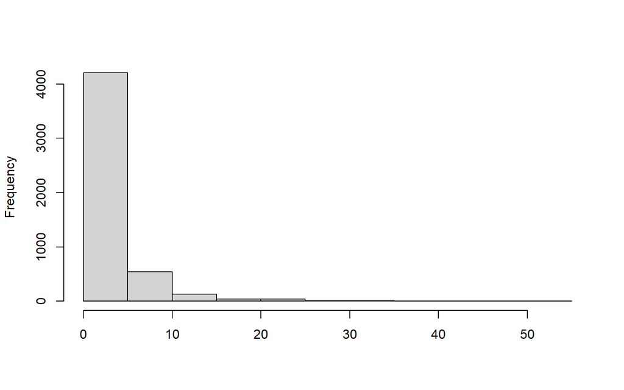

```r
maha_dist(nh_smaller, keep.NA = FALSE) %>% hist(main = "", xlab = "")
```

We may have a heavy outlier or incorrect entry here. Let us check it out using the `insist_rows` function, which takes in a data frame, a row reduction function, a predicate-generating function, and whatever columns to apply the predicate on.

It will raise an error if it finds any violations.

```r
nh_smaller %>%
  insist_rows(maha_dist, within_n_mads(3), everything())
```

```
## Data frame row reduction 'maha_dist' violates predicate 'within_n_mads(3)' 167 times
##          verb  redux_fn        predicate        column index    value
## 1 insist_rows maha_dist within_n_mads(3) ~everything()  2477 10.61986
## 2 insist_rows maha_dist within_n_mads(3) ~everything()  2478 10.61986
## 3 insist_rows maha_dist within_n_mads(3) ~everything()  2511 10.35621
## 4 insist_rows maha_dist within_n_mads(3) ~everything()  2536 17.69782
## 5 insist_rows maha_dist within_n_mads(3) ~everything()  2543 11.91619
##   [omitted 162 rows]
```

```
## Error: assertr stopped execution
```

This function is running the `maha_dist` function on the entire `nh_smaller` dataframe and checked that the values fells within 3 median absolute deviations.

```r
nh %>%
  insist_rows(row_reduction_fn = maha_dist,
              predicate_generator = within_n_mads(3),
              c(BMI, Testosterone, AlcoholDay))
```

```
## Data frame row reduction 'maha_dist' violates predicate 'within_n_mads(3)' 328 times
##          verb  redux_fn        predicate                            column
## 1 insist_rows maha_dist within_n_mads(3) ~c(BMI, Testosterone, AlcoholDay)
## 2 insist_rows maha_dist within_n_mads(3) ~c(BMI, Testosterone, AlcoholDay)
## 3 insist_rows maha_dist within_n_mads(3) ~c(BMI, Testosterone, AlcoholDay)
## 4 insist_rows maha_dist within_n_mads(3) ~c(BMI, Testosterone, AlcoholDay)
## 5 insist_rows maha_dist within_n_mads(3) ~c(BMI, Testosterone, AlcoholDay)
##   index    value
## 1  5020 8.005804
## 2  5031 4.711700
## 3  5032 5.165139
## 4  5033 5.165139
## 5  5034 5.165139
##   [omitted 323 rows]
```

```
## Error: assertr stopped execution
```

This is probably the most powerful construct in assertr–it can find a whole lot of nasty errors that would be very difficult to check for by hand.

Part of what makes it so powerful is how flexible maha_dist is. We only used it, so far, on a data frame of numerics, but it can handle all sorts of data frames.

`assert` has a row-oriented counterpart, too; it’s called `assert_rows`. `assert_rows` works the same as `insist_rows`, except that instead of using a predicate generator on the row-reduced data frame, it uses a normal predicate.

```r
nh_smaller %>%
    assert_rows(num_row_NAs, within_bounds(0,3), everything())
```

```
## Data frame row reduction 'num_row_NAs' violates predicate 'within_bounds(0, 3)' 151 times
##          verb    redux_fn           predicate        column index value
## 1 assert_rows num_row_NAs within_bounds(0, 3) ~everything()    37     4
## 2 assert_rows num_row_NAs within_bounds(0, 3) ~everything()   173     4
## 3 assert_rows num_row_NAs within_bounds(0, 3) ~everything()   188     4
## 4 assert_rows num_row_NAs within_bounds(0, 3) ~everything()   191     4
## 5 assert_rows num_row_NAs within_bounds(0, 3) ~everything()   266     4
##   [omitted 146 rows]
```

```
## Error: assertr stopped execution
```

## Using `success`, `error`, and `defect` to change the behavior of `assert`, `insist`, and `verify`.

“The behavior of functions like assert, assert_rows, insist, insist_rows, verify when the assertion passes, fails or is skipped due to data defect is configurable via the success_fun, error_fun and defect_fun parameters, respectively.”

The `success_fun` parameter takes a function that takes the data passed to the assertion function as a parameter. You can write your own success handler function, but there are a few provided by this package:

- `success_continue` - just returns the data that was passed into the assertion function (this is default).
- `success_logical` - returns TRUE
- `success_append` - returns the data that was passed into the assertion function but also attaches basic information about verification result to a special attribute of data.
- `success_report` - when success results are stored (chain_start(store_results=TRUE)), and each verification ended up with success, it prints a summary of all successful validations (when being in chan) or simple verification result for single check and returns data.
- `success_df_return` - when success results are stored (chain_start(store_results=TRUE)), and each verification ended up with success, it prints data.frame with verification results (can be used for chain_end or single verification).

```r
## CHANGING THE RESULTS OF A SUCCESSFUL ASSERTION
nh %>%
  mutate(Gender = as.character(Gender)) %>%
  assert(char.4.6, Gender, success_fun = success_logical)
```

```
## [1] TRUE
```

```r
nh %>%
  mutate(Gender = as.character(Gender)) %>%
  assert(char.4.6, Gender, success_fun = success_report)
```

```
## assert: verification [char.4.6] passed! Verified columns: Gender
```

The `error_fun` parameter takes a function that takes the data passed to the assertion function as a parameter. You can write your own error handler function, but there are a few provided by this package:

- `error_stop` - Prints a summary of the errors and halts execution (default)
- `error_report` - Prints all the information available about the errors and halts execution.
- `error_append` - Attaches the errors to a special attribute of data and returns the data. This is chiefly to allow assertr errors to be accumulated in a pipeline so that all assertions can have a chance to be checked and so that all the errors can be displayed at the end of the chain.
- `error_logical` - returns FALSE
- `just_warn` - Prints a summary of the errors but does not halt execution, it just issues a warning.
- `warn_report` - Prints all the information available about the errors but does not halt execution, it just issues a warning.
- `defect_report` - For single rule and defective data it displays short info about skipping the current assertion. For chain_end sums up all skipped rules for defective data.
- `defect_df_return` - For single rule and defective data it returns info data.frame about skipping current assertion. For chain_end returns all skipped rules info data.frame for defective data.

```r
## Default Assertion
nh %>%
  mutate(Race1 = as.character(Race1)) %>%
  assert(function(x) (nchar(x) == 4 | nchar(x) == 6), Race1)
```

```
## Column 'Race1' violates assertion 'function(x) (nchar(x) == 4 | nchar(x) == 6)' 10000 times
##     verb redux_fn                                   predicate column index
## 1 assert       NA function(x) (nchar(x) == 4 | nchar(x) == 6)  Race1     1
## 2 assert       NA function(x) (nchar(x) == 4 | nchar(x) == 6)  Race1     2
## 3 assert       NA function(x) (nchar(x) == 4 | nchar(x) == 6)  Race1     3
## 4 assert       NA function(x) (nchar(x) == 4 | nchar(x) == 6)  Race1     4
## 5 assert       NA function(x) (nchar(x) == 4 | nchar(x) == 6)  Race1     5
##   value
## 1 White
## 2 White
## 3 White
## 4 Other
## 5 White
##   [omitted 9995 rows]
```

```
## Error: assertr stopped execution
```

```r
## CHANGING THE RESULTS OF A UNSUCCESSFUL ASSERTION
nh %>%
  mutate(Race1 = as.character(Race1)) %>%
  assert(function(x) (nchar(x) == 4 | nchar(x) == 6), Race1,
         error_fun= just_warn) # Just warns, but allows it to run.
```

```
## Column 'Race1' violates assertion 'function(x) (nchar(x) == 4 | nchar(x) == 6)' 10000 times
##     verb redux_fn                                   predicate column index
## 1 assert       NA function(x) (nchar(x) == 4 | nchar(x) == 6)  Race1     1
## 2 assert       NA function(x) (nchar(x) == 4 | nchar(x) == 6)  Race1     2
## 3 assert       NA function(x) (nchar(x) == 4 | nchar(x) == 6)  Race1     3
## 4 assert       NA function(x) (nchar(x) == 4 | nchar(x) == 6)  Race1     4
## 5 assert       NA function(x) (nchar(x) == 4 | nchar(x) == 6)  Race1     5
##   value
## 1 White
## 2 White
## 3 White
## 4 Other
## 5 White
##   [omitted 9995 rows]
```

```
## # A tibble: 10,000 x 76
##       ID SurveyYr Gender   Age AgeDecade AgeMonths Race1 Race3 Education
##    <int> <fct>    <fct>  <int> <fct>         <int> <chr> <fct> <fct>
##  1 51624 2009_10  male      34 " 30-39"        409 White <NA>  High School
##  2 51624 2009_10  male      34 " 30-39"        409 White <NA>  High School
##  3 51624 2009_10  male      34 " 30-39"        409 White <NA>  High School
##  4 51625 2009_10  male       4 " 0-9"           49 Other <NA>  <NA>
##  5 51630 2009_10  female    49 " 40-49"        596 White <NA>  Some College
##  6 51638 2009_10  male       9 " 0-9"          115 White <NA>  <NA>
##  7 51646 2009_10  male       8 " 0-9"          101 White <NA>  <NA>
##  8 51647 2009_10  female    45 " 40-49"        541 White <NA>  College Grad
##  9 51647 2009_10  female    45 " 40-49"        541 White <NA>  College Grad
## 10 51647 2009_10  female    45 " 40-49"        541 White <NA>  College Grad
## # ... with 9,990 more rows, and 67 more variables: MaritalStatus <fct>,
## #   HHIncome <fct>, HHIncomeMid <int>, Poverty <dbl>, HomeRooms <int>,
## #   HomeOwn <fct>, Work <fct>, Weight <dbl>, Length <dbl>, HeadCirc <dbl>,
## #   Height <dbl>, BMI <dbl>, BMICatUnder20yrs <fct>, BMI_WHO <fct>,
## #   Pulse <dbl>, BPSysAve <int>, BPDiaAve <int>, BPSys1 <int>, BPDia1 <int>,
## #   BPSys2 <int>, BPDia2 <int>, BPSys3 <int>, BPDia3 <int>, Testosterone <dbl>,
## #   DirectChol <dbl>, TotChol <dbl>, UrineVol1 <int>, UrineFlow1 <dbl>, ...
```

```r
nh %>%
  mutate(Race1 = as.character(Race1)) %>%
  assert(function(x) (nchar(x) == 4 | nchar(x) == 6), Race1, error_fun = error_report)
```

```
## There are 10000 errors across 1 verb:
## -
##         verb redux_fn                                   predicate column index
## 1     assert       NA function(x) (nchar(x) == 4 | nchar(x) == 6)  Race1     1
## 2     assert       NA function(x) (nchar(x) == 4 | nchar(x) == 6)  Race1     2
## 3     assert       NA function(x) (nchar(x) == 4 | nchar(x) == 6)  Race1     3
## 4     assert       NA function(x) (nchar(x) == 4 | nchar(x) == 6)  Race1     4
## 5     assert       NA function(x) (nchar(x) == 4 | nchar(x) == 6)  Race1     5
## 6     assert       NA function(x) (nchar(x) == 4 | nchar(x) == 6)  Race1     6
## 7     assert       NA function(x) (nchar(x) == 4 | nchar(x) == 6)  Race1     7
## 8     assert       NA function(x) (nchar(x) == 4 | nchar(x) == 6)  Race1     8
## 9     assert       NA function(x) (nchar(x) == 4 | nchar(x) == 6)  Race1     9
## 10    assert       NA function(x) (nchar(x) == 4 | nchar(x) == 6)  Race1    10
## 11    assert       NA function(x) (nchar(x) == 4 | nchar(x) == 6)  Race1    11
## 12    assert       NA function(x) (nchar(x) == 4 | nchar(x) == 6)  Race1    12
```

[output cut: 19989 more lines]

```
## Error: assertr stopped execution
```

The `defect_fun` parameter takes a function that takes the data passed to the assertion function as a parameter. Defect handler is called when any of previous assertions that was marked as obligatory failed (see below section). You can write your own defect handler function, but there are a few provided by this package:

- `defect_append` - Attaches the assertion call info on defective data to a special attribute of data and returns the data.
- `defect_report` - For single rule and defective data it displays short info about skipping current assertion. For chain_end sums up all skipped rules for defective data.
- `defect_df_return` - For single rule and defective data it returns info data.frame about skipping current assertion. For chain_end returns all skipped rules info data.frame for defective data.

```r
nh %>%
  mutate(Race1 = as.character(Race1)) %>%
  assert(function(x) (nchar(x) == 4 | nchar(x) == 6), Race1, error_fun = defect_report)
```

```
## Error in defect_append(errors, data, ...): the ... list contains fewer than 1 element
```

# Combining Assertions

When you run a series of assert steps, when one hits an error, it will stop running the code. However, you can use a special function to run through all of the assertion steps before erroring out. This is done using the `chain_start` and `chain_end` functions.

```r
nh %>%
    assert(not_na, Testosterone) %>%  ## Will Stop here
    assert(within_bounds(0, 60), Age) %>%
    assert(in_set(c("No", "Yes")), SmokeNow, HardDrugs) %>%
    assert(is_uniq, ID) %>%

nh %>%
  chain_start %>%
    assert(not_na, Testosterone) %>%
    assert(within_bounds(0, 60), Age) %>%
    assert(in_set(c("No", "Yes")), SmokeNow, HardDrugs) %>%
    assert(is_uniq, ID) %>%
  chain_end
```

```
## Error in nh(.): could not find function "nh"
```

Let’s try and abstractify this portion so we can run it often.

```r
check_me <- . %>%
  chain_start %>%
    verify(nrow(nh_smaller) > 5000) %>%
    verify(BMI > 0) %>%
    insist(within_n_sds(4), BPSysAve) %>%
    assert(not_na, Testosterone) %>%
  chain_end

check_me
```

```
## Functional sequence with the following components:
##
##  1. chain_start(.)
##  2. verify(., nrow(nh_smaller) > 5000)
##  3. verify(., BMI > 0)
##  4. insist(., within_n_sds(4), BPSysAve)
##  5. assert(., not_na, Testosterone)
##  6. chain_end(.)
##
## Use 'functions' to extract the individual functions.
```

```r
nh_smaller %>%
  check_me %>%
  summarise(avg.BPSYS = mean(BPSysAve, na.rm = TRUE))
```

```
## There are 3111 errors across 4 verbs:
## -
##        verb redux_fn               predicate       column index value
## 1    verify       NA nrow(nh_smaller) > 5000         <NA>     1    NA
## 2    verify       NA                 BMI > 0         <NA>    37    NA
## 3    verify       NA                 BMI > 0         <NA>   153    NA
## 4    verify       NA                 BMI > 0         <NA>   154    NA
## 5    verify       NA                 BMI > 0         <NA>   161    NA
## 6    verify       NA                 BMI > 0         <NA>   173    NA
## 7    verify       NA                 BMI > 0         <NA>   188    NA
## 8    verify       NA                 BMI > 0         <NA>   191    NA
## 9    verify       NA                 BMI > 0         <NA>   266    NA
## 10   verify       NA                 BMI > 0         <NA>   268    NA
## 11   verify       NA                 BMI > 0         <NA>   271    NA
## 12   verify       NA                 BMI > 0         <NA>   281    NA
```

[output cut: 3099 more lines]

```
## Error: assertr stopped execution
```